# Rahul Khandekar

```r
library(tidyverse)
library(dplyr)
library(tidyr)
library(cluster)
library(ggplot2)
library(lmtest)
library(sandwich)
library(vegan)
library(tidyverse)
library(dplyr)
select<-dplyr::select
data_1<-read.csv("data 1.csv")
data_2<-read.csv("data 2.csv")
data_2 %>% inner_join(data_1, by="ï..ID") %>% na.omit() %>% glimpse()
```

```
Rows: 202
Columns: 14
$ ï..ID  <int> 1, 2, 3, 4, 5, 6, 7, 8, 9, 10, 11, 12, 13, 14, 15, 16, 17, 18, 19, 20, 21, 22, 23, 24, 25, 26, 27, 28, 2...
$ ssf    <dbl> 109.1, 102.8, 104.6, 126.4, 80.3, 75.2, 87.2, 97.9, 75.1, 65.1, 171.1, 76.8, 117.8, 90.2, 97.2, 99.9, 12...
$ pcBfat <dbl> 19.75, 21.30, 19.88, 23.66, 17.64, 15.58, 19.99, 22.43, 17.95, 15.07, 28.83, 18.08, 23.30, 17.71, 18.77,...
$ lbm    <dbl> 63.32, 58.55, 55.36, 57.18, 53.20, 53.77, 60.17, 48.33, 54.57, 53.42, 68.53, 61.85, 48.32, 66.24, 57.92,...
$ ht     <dbl> 195.9, 189.7, 177.8, 185.0, 184.6, 174.0, 186.2, 173.8, 171.4, 179.9, 193.4, 188.7, 169.1, 177.9, 177.5,...
$ wt     <dbl> 78.9, 74.4, 69.1, 74.9, 64.6, 63.7, 75.2, 62.3, 66.5, 62.9, 96.3, 75.5, 63.0, 80.5, 71.3, 70.5, 73.2, 68...
$ sex    <chr> "f", "f", "f", "f", "f", "f", "f", "f", "f", "f", "f", "f", "f", "f", "f", "f", "f", "f", "f", "f", "f",...
$ sport  <chr> "B_Ball", "B_Ball", "B_Ball", "B_Ball", "B_Ball", "B_Ball", "B_Ball", "B_Ball", "B_Ball", "B_Ball", "B_B...
$ rcc    <dbl> 3.96, 4.41, 4.14, 4.11, 4.45, 4.10, 4.31, 4.42, 4.30, 4.51, 4.71, 4.62, 4.35, 4.26, 4.63, 4.36, 3.91, 4....
$ wcc    <dbl> 7.5, 8.3, 5.0, 5.3, 6.8, 4.4, 5.3, 5.7, 8.9, 4.4, 5.3, 7.3, 7.8, 6.2, 6.0, 5.8, 7.3, 8.3, 8.1, 6.9, 5.7,...
$ hc     <dbl> 37.5, 38.2, 36.4, 37.3, 41.5, 37.4, 39.6, 39.9, 41.1, 41.6, 41.4, 43.8, 41.4, 41.0, 43.7, 40.3, 37.6, 43...
$ hg     <dbl> 12.3, 12.7, 11.6, 12.6, 14.0, 12.5, 12.8, 13.2, 13.5, 12.7, 14.0, 14.7, 14.1, 13.9, 14.7, 13.3, 12.9, 14...
$ ferr   <int> 60, 68, 21, 69, 29, 42, 73, 44, 41, 44, 38, 26, 30, 48, 30, 29, 43, 34, 53, 59, 43, 40, 92, 48, 77, 71, ...
$ bmi    <dbl> 20.56, 20.67, 21.86, 21.88, 18.96, 21.04, 21.69, 20.62, 22.64, 19.44, 25.75, 21.20, 22.03, 25.44, 22.63,...
```

```r
data_3 <- data_2 %>% inner_join(data_1, by="ï..ID") %>% na.omit() %>% glimpse()
```

```
Rows: 202
Columns: 14
$ ï..ID  <int> 1, 2, 3, 4, 5, 6, 7, 8, 9, 10, 11, 12, 13, 14, 15, 16, 17, 18, 19, 20, 21, 22, 23, 24, 25, 26, 27, 28, 2...
$ ssf    <dbl> 109.1, 102.8, 104.6, 126.4, 80.3, 75.2, 87.2, 97.9, 75.1, 65.1, 171.1, 76.8, 117.8, 90.2, 97.2, 99.9, 12...
$ pcBfat <dbl> 19.75, 21.30, 19.88, 23.66, 17.64, 15.58, 19.99, 22.43, 17.95, 15.07, 28.83, 18.08, 23.30, 17.71, 18.77,...
$ lbm    <dbl> 63.32, 58.55, 55.36, 57.18, 53.20, 53.77, 60.17, 48.33, 54.57, 53.42, 68.53, 61.85, 48.32, 66.24, 57.92,...
$ ht     <dbl> 195.9, 189.7, 177.8, 185.0, 184.6, 174.0, 186.2, 173.8, 171.4, 179.9, 193.4, 188.7, 169.1, 177.9, 177.5,...
$ wt     <dbl> 78.9, 74.4, 69.1, 74.9, 64.6, 63.7, 75.2, 62.3, 66.5, 62.9, 96.3, 75.5, 63.0, 80.5, 71.3, 70.5, 73.2, 68...
$ sex    <chr> "f", "f", "f", "f", "f", "f", "f", "f", "f", "f", "f", "f", "f", "f", "f", "f", "f", "f", "f", "f", "f",...
$ sport  <chr> "B_Ball", "B_Ball", "B_Ball", "B_Ball", "B_Ball", "B_Ball", "B_Ball", "B_Ball", "B_Ball", "B_Ball", "B_B...
$ rcc    <dbl> 3.96, 4.41, 4.14, 4.11, 4.45, 4.10, 4.31, 4.42, 4.30, 4.51, 4.71, 4.62, 4.35, 4.26, 4.63, 4.36, 3.91, 4....
$ wcc    <dbl> 7.5, 8.3, 5.0, 5.3, 6.8, 4.4, 5.3, 5.7, 8.9, 4.4, 5.3, 7.3, 7.8, 6.2, 6.0, 5.8, 7.3, 8.3, 8.1, 6.9, 5.7,...
$ hc     <dbl> 37.5, 38.2, 36.4, 37.3, 41.5, 37.4, 39.6, 39.9, 41.1, 41.6, 41.4, 43.8, 41.4, 41.0, 43.7, 40.3, 37.6, 43...
$ hg     <dbl> 12.3, 12.7, 11.6, 12.6, 14.0, 12.5, 12.8, 13.2, 13.5, 12.7, 14.0, 14.7, 14.1, 13.9, 14.7, 13.3, 12.9, 14...
$ ferr   <int> 60, 68, 21, 69, 29, 42, 73, 44, 41, 44, 38, 26, 30, 48, 30, 29, 43, 34, 53, 59, 43, 40, 92, 48, 77, 71, ...
$ bmi    <dbl> 20.56, 20.67, 21.86, 21.88, 18.96, 21.04, 21.69, 20.62, 22.64, 19.44, 25.75, 21.20, 22.03, 25.44, 22.63,...
```

```r
nrow(data_3)
```

```
[1] 202
```

```r
ncol(data_3)
```

```
[1] 14
```

I used the “ais” dataset, which has physical characteristics of Australian athletes and divides them on the sport they play. I broke the dataset into two separate datasets, and then I used an “inner join” function to merge them together. There are 12 numerical variables (physical characteristics) and 2 categorical variables (sport type and sex). The “sex” variable was treated as a binary variable with males and females as the two options which can be used. BMI was used as a numerical variable, and this refers to an athlete’s body mass index. “Ht” refers to the height of an athlete, and “wt” refers to the weight of an athlete. The categorical variable of “sport” indicates which sport an athlete competed in.

#1

```r
gg3<-ggplot(data_3, aes(x = ht, y = wt)) + geom_point(alpha = .5) + geom_density_2d(h=2) + coord_fixed() + facet_wrap(~bmi)
manva<-manova(cbind(ht,wt)~sport, data=data_3)
summary(manva)
```

```
           Df  Pillai approx F num Df den Df    Pr(>F)
sport       9 0.78279   13.719     18    384 < 2.2e-16 ***
Residuals 192
---
Signif. codes:  0 ‘***’ 0.001 ‘**’ 0.01 ‘*’ 0.05 ‘.’ 0.1 ‘ ’ 1
```

```r
summary.aov(manva)
```

```
 Response ht :
             Df  Sum Sq Mean Sq F value    Pr(>F)
sport         9  7592.1  843.57   14.14 < 2.2e-16 ***
Residuals   192 11454.7   59.66
---
Signif. codes:  0 ‘***’ 0.001 ‘**’ 0.01 ‘*’ 0.05 ‘.’ 0.1 ‘ ’ 1

 Response wt :
             Df Sum Sq Mean Sq F value    Pr(>F)
sport         9  17121 1902.27  16.711 < 2.2e-16 ***
Residuals   192  21856  113.83
---
Signif. codes:  0 ‘***’ 0.001 ‘**’ 0.01 ‘*’ 0.05 ‘.’ 0.1 ‘ ’ 1
```

```r
manva6<-manova(cbind(ht,wt)~sex, data=data_3)
summary(manva6)
```

```
           Df  Pillai approx F num Df den Df    Pr(>F)
sex         1 0.34538   52.497      2    199 < 2.2e-16 ***
Residuals 200
---
Signif. codes:  0 ‘***’ 0.001 ‘**’ 0.01 ‘*’ 0.05 ‘.’ 0.1 ‘ ’ 1
```

```r
summary.aov(manva6)
```

```
 Response ht :
             Df  Sum Sq Mean Sq F value    Pr(>F)
sex           1  6012.4  6012.4  92.254 < 2.2e-16 ***
Residuals   200 13034.4    65.2
---
Signif. codes:  0 ‘***’ 0.001 ‘**’ 0.01 ‘*’ 0.05 ‘.’ 0.1 ‘ ’ 1

 Response wt :
             Df Sum Sq Mean Sq F value    Pr(>F)
sex           1  11638 11638.0  85.141 < 2.2e-16 ***
Residuals   200  27338   136.7
---
Signif. codes:  0 ‘***’ 0.001 ‘**’ 0.01 ‘*’ 0.05 ‘.’ 0.1 ‘ ’ 1
```

```r
data_3%>% group_by(sport)%>% summarise(mean(ht),mean(wt))
```

| sport | mean(ht) | mean(wt) |
| --- | --- | --- |
| B_Ball | 188.6600 | 79.77600 |
| Field | 180.6000 | 89.96842 |
| Gym | 153.4250 | 43.62500 |
| Netball | 176.0870 | 69.59130 |
| Row | 182.3757 | 78.53784 |
| Swim | 180.5455 | 75.14545 |
| T_400m | 175.4517 | 64.04828 |
| T_Sprnt | 176.3867 | 71.50667 |
| Tennis | 174.1636 | 64.47273 |
| W_Polo | 188.2235 | 86.72941 |

```r
data_3%>% group_by(sex)%>% summarise(mean(ht),mean(wt))
```

| sex | mean(ht) | mean(wt) |
| --- | --- | --- |
| f | 174.5940 | 67.34200 |
| m | 185.5059 | 82.52353 |

```r
1-(.95)^3
```

```
[1] 0.142625
```

```r
.05/3
```

```
[1] 0.01666667
```

After running a MANOVA test across two numeric variables, height “ht” and weight “wt”, there was a significant difference found across the categorical variables of sport “sport” and gender “sex”. The null hypothesis is that there is not a significant difference for height or weight for the categorical variables. The alternate hypothesis is that there is a significant difference between the variables for height and weight. By running a MANOVA test, we assume that samples are observed independently, there are no multivariate outliers, there is a sample size of at least 25, and there is no collinearity. The assumptions were probably not all met, as there are outliers since it is a comprehensive record of all Australian athletes. The summary statistics show that there is a significant difference between at least one of the groups. Because of this, a post hoc test was run to see which groups differed and if multiple groups did, how many of them differed. The p value of (<2.2e-16) shows there is a significant difference. The height “ht” and weight “wt” numeric variables both had significant differences across the gender “sex” binomial variable. Therefore, the null hypothesis that there is no significant difference across genders for height or weight is rejected. The same test was run but with sport as the categorical variable, and the null hypothesis was rejected once again with a p values of <2.2e-16. After this, the probability of a type one error was found. Because three tests were run, the equation of 1-(.95)^3 gave the probability of a type one error as 0.142625. Neither of the ANOVA tests support the null hypothesis as they both gave p values below 2.2e-16. I then did a bonferroni correction and this equation is given by 0.05/3= 0.01666667. Both of the tests still reject the null hypothesis as p < 2.2e-16 is less than 0.017. Therefore, the MANOVA and ANOVA tests gave the same result of significant differences between height and weight across sexes.

#2

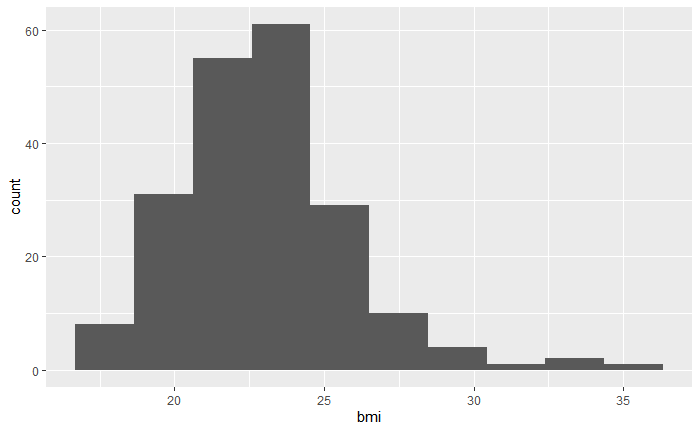

```r
ggplot(data_3,aes(bmi,fill= wt+ht+(wt*ht)))+geom_histogram(bins=10)
```

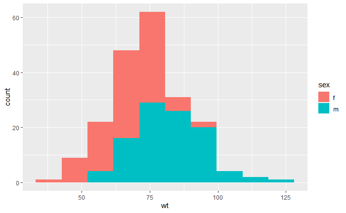

```r
ggplot(data_3,aes(wt,fill= sex))+geom_histogram(bins=10)
```

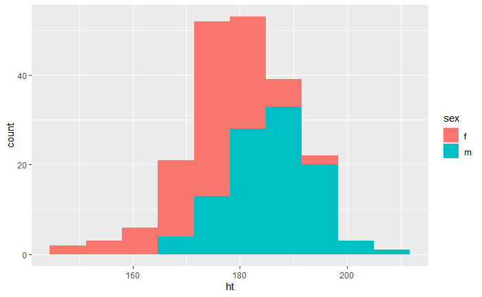

```r
ggplot(data_3,aes(ht,fill= sex))+geom_histogram(bins=10)
```

```r
d1 <- data_3%>%select(ht,wt)%>%dist()
library(vegan)
adonis(d1~sex,data=data_3)
```

```
Call:
adonis(formula = d1 ~ sex, data = data_3)

Permutation: free
Number of permutations: 999

Terms added sequentially (first to last)

           Df SumsOfSqs MeanSqs F.Model     R2 Pr(>F)
sex         1     17650 17650.4  87.438 0.3042  0.001 ***
Residuals 200     40373   201.9         0.6958
Total     201     58023                 1.0000
---
Signif. codes:  0 ‘***’ 0.001 ‘**’ 0.01 ‘*’ 0.05 ‘.’ 0.1 ‘ ’ 1
```

```r
linearMod <- lm(ht ~ wt, data=data_3)
r1<-lm(bmi~ht, data=data_3)$residuals
r2<-lm(bmi~wt,data=data_3)$residuals
coef(lm(r1~r2))
```

```
  (Intercept)            r2
-3.382826e-17  1.383471e+00
```

```r
coef(lm(bmi~ht*wt,data=data_3))
```

```
 (Intercept)           ht           wt        ht:wt
19.175085998 -0.106036730  0.653526612 -0.001920094
```

```r
linearMod
```

```
Call:
lm(formula = ht ~ wt, data = data_3)

Coefficients:
(Intercept)           wt
   139.1560       0.5459
```

```r
summary(linearMod)
```

```
Call:
lm(formula = ht ~ wt, data = data_3)

Residuals:
     Min       1Q   Median       3Q      Max
-19.1240  -3.9482   0.3684   4.5999  14.8274

Coefficients:
             Estimate Std. Error t value Pr(>|t|)
(Intercept) 139.15599    2.35526   59.08   <2e-16 ***
wt            0.54592    0.03088   17.68   <2e-16 ***
---
Signif. codes:  0 ‘***’ 0.001 ‘**’ 0.01 ‘*’ 0.05 ‘.’ 0.1 ‘ ’ 1

Residual standard error: 6.096 on 200 degrees of freedom
Multiple R-squared:  0.6099,    Adjusted R-squared:  0.6079
F-statistic: 312.6 on 1 and 200 DF,  p-value: < 2.2e-16
```

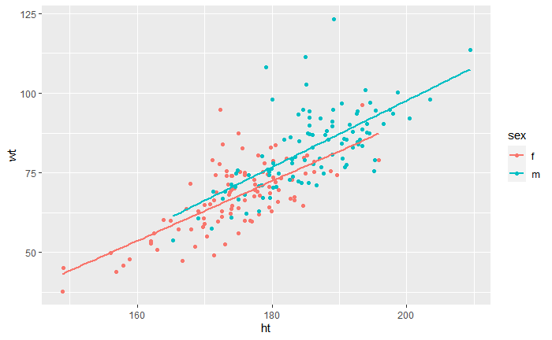

```r
ggplot(data=data_3,aes(x=ht,y=wt,color=sex))+geom_point()+geom_smooth(method="lm",se=FALSE)
```

```r
library(lmtest)
library(sandwich)
bptest(linearMod)
```

```
    studentized Breusch-Pagan test

data:  linearMod
BP = 16.97, df = 1, p-value = 3.797e-05
```

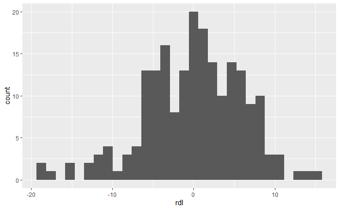

```r
ftvl <-linearMod$fitted.values
rdl <-linearMod$residuals
ggplot()+geom_histogram(aes(rdl),bins = 30)
```

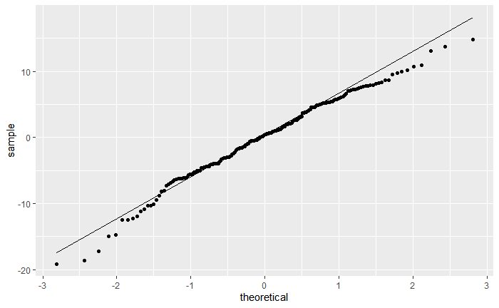

```r
ggplot() +geom_qq(aes(sample=rdl)) + geom_qq_line(aes(sample=rdl))
```

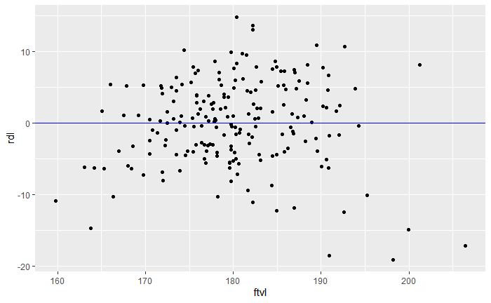

```r
ggplot()+geom_point(aes(ftvl,rdl))+geom_hline(yintercept = 0, color='blue')
```

```r
summary(linearMod)$coef[,1:2]
```

```
               Estimate Std. Error
(Intercept) 139.1559917 2.35526315
wt            0.5459153 0.03087522
```

The null hypothesis is that there is not a significant difference between the two genders for height and weight, and the alternate hypothesis is that there is a significant difference between the two sexes for height and weight. I ran a permanova test to analyze the multivariate data, and with a p value of 0.001, the null hypothesis is rejected.